# CRC summary statistics

# Identify relevant workspaces

This notebook is intended to illustrate combining data from multiple PRIMED workspaces for an analysis. We will take the example of a researcher studying colorectal cancer who wants to use summary statistics from two studies: the UKBB and published results from a GWAS. Both studies are available in PRIMED open access workspaces.

- https://anvil.terra.bio/#workspaces/primed-data-cc-open/PRIMED_PAN_UKBB_GSR_CANCER
- https://anvil.terra.bio/#workspaces/primed-data-primed-cancer-open/PRIMED_CRC_PMID36539618

To fetch data from a workspace, we need two pieces of information: the workspace name and the namespace, also known as the billing project. The URL for every AnVIL workspace takes the form `<https://anvil.terra.bio/#workspaces/namespace/workspace_name>`. Therefore, we can always find this information for a workspace by navigating to it in the Workspaces menu on the AnVIL platform. Based on the URLs listed above, we can identify the workspace names and namespaces to be:

```r
ukbb_workspace <- "PRIMED_PAN_UKBB_GSR_CANCER"
ukbb_namespace <- "primed-data-cc-open"
crc_workspace <- "PRIMED_CRC_PMID36539618"
crc_namespace <- "primed-data-primed-cancer-open"
```

# Retrieve data from UKBB workspace

```r
library(AnVIL)
```

There are four analyses of colorectal cancer, in different populations. Each row in the `analysis` table is assigned an `analysis_id` when it is imported to AnVIL, which is the primary key for this table.

```r
ukbb_crc <- ukbb_analysis %>%
  filter(trait == "Colorectal cancer")

select(ukbb_crc, analysis_id, trait, population_descriptor, population_labels)
```

| analysis_id | trait | population_descriptor | population_labels |
| --- | --- | --- | --- |
| 57dbb706 | Colorectal cancer | Genetic ancestry group | African ancestry |
| 3934a072 | Colorectal cancer | Genetic ancestry group | Central/South Asian ancestry |
| 93f9b24b | Colorectal cancer | Genetic ancestry group | African ancestry \| Central/South Asian ancestry \| European ancestry |
| e973cddb | Colorectal cancer | Genetic ancestry group | European ancestry |

The `gsr_file` table contains bucket paths to the data from these analyses, one file per row. See the PRIMED Data Model for details on all of the columns in this table. The `analysis_id` links the analysis to files in the `gsr_file` table, so we use it to identify the files in the `gsr_file` table corresponding to the analysis we want (in this case, the files from the multi-population analysis).

```r
ukbb_gsr_file <- avtable("gsr_file",
                    name = ukbb_workspace,
                    namespace = ukbb_namespace) %>%
  filter(analysis_id == "93f9b24b")

select(ukbb_gsr_file, analysis_id, chromosome, file_path) %>%
  head(n=2)
```

| analysis_id | chromosome | file_path |
| --- | --- | --- |
| 93f9b24b | 1 | gs://fc-757b62a0-690c-4f9d-a2e9-7b6e1f5bd496/UKBB-Data/153_N/153_N_meta_1_data.tsv.gz |
| 93f9b24b | 10 | gs://fc-757b62a0-690c-4f9d-a2e9-7b6e1f5bd496/UKBB-Data/153_N/153_N_meta_10_data.tsv.gz |

```r
count(ukbb_gsr_file, analysis_id)
```

| analysis_id | n |
| --- | --- |
| 93f9b24b | 23 |

This analysis has 23 files, one file per chromosome. We use the `gsutil_cp()` function to copy the files to our current cloud environment.

```r
dir.create("UKBB_CRC")
gsutil_cp(ukbb_gsr_file$file_path, "UKBB_CRC")
```

# Retrieve data from GWAS workspace

The CRC GWAS workspace contains only a single analysis.

```r
crc_analysis <- avtable("analysis",
                    name = crc_workspace,
                    namespace = crc_namespace)

select(crc_analysis, analysis_id, trait, population_descriptor, population_labels)
```

| analysis_id | trait | population_descriptor | population_labels |
| --- | --- | --- | --- |
| 0d5a1386376bf54b | colorectal cancer | reported ancestry | European \| East Asian |

The `gsr_file` table contains bucket paths to the data for this analysis.

```r
crc_gsr_file <- avtable("gsr_file",
                    name = crc_workspace,
                    namespace = crc_namespace)
```

This analysis has only one associated file, with the results for all chromosomes. We use the `gsutil_cp()` function to copy the files to our current cloud environment.

```r
dir.create("GWAS_CRC")
gsutil_cp(crc_gsr_file$file_path, "GWAS_CRC")
```

# Write data tables to the workspace

To more easily keep track of the data we’re working with, we can create `analysis` and `gsr_file` tables in this workspace. Since all data is in the PRIMED data model, it is straightforward to concatenate tables. The AnVIL package has a function to import data tables to a workspace. The `entity` argument should contain the primary key for the table.

```r
bind_rows(crc_analysis, ukbb_analysis) %>%
  avtable_import()
```

```
pageSize = 27 rows (1 pages)
```

# Read in summary statistics

Since we have already copied the GSR files to our compute environment, we can read a file into R.

```r
library(readr)

ukbb_chr22_file <- ukbb_gsr_file %>%
  filter(chromosome == 22) %>%
  select(file_path) %>%
  unlist() %>%
  basename()

ukbb_chr22 <- read_tsv(file.path("UKBB_CRC", ukbb_chr22_file))
head(ukbb_chr22)
```

| SNPID | chromosome | position | rsID | strand | effect_allele | other_allele | ref_allele | alt_allele | effect_allele_freq | eaf_case | eaf_ctrl | p_value | p_value_log10 | beta | se | beta_ci_lower | beta_ci_upper | odds_ratio | OR_ci_lower | OR_ci_upper | direction_of_effect | imputation_quality_score | heterogeneity_p_value |
| --- | --- | --- | --- | --- | --- | --- | --- | --- | --- | --- | --- | --- | --- | --- | --- | --- | --- | --- | --- | --- | --- | --- | --- |
| 22:16051249:T:C | 22 | 16051249 | rs62224609 | forward | C | T | T | C | 0.1033057049 | 0.1037000 | 0.1033000 | 0.7281150 | 0.13780 | 0.011240 | 0.03232 | -0.05210604 | 0.07458604 | 1.011303 | 0.9492282 | 1.077438 | + | 0.96932 | 0.2737789 |
| 22:16052962:C:T | 22 | 16052962 | rs376238049 | forward | T | C | C | T | 0.0914274164 | 0.0919400 | 0.0914200 | 0.7334998 | 0.13460 | 0.012520 | 0.03676 | -0.05952828 | 0.08456828 | 1.012599 | 0.9422089 | 1.088247 | + | 0.83020 | 0.3207008 |
| 22:16053862:C:T | 22 | 16053862 | rs62224614 | forward | T | C | C | T | 0.1049942951 | 0.1046000 | 0.1050000 | 0.8849730 | 0.05307 | 0.004635 | 0.03204 | -0.05816225 | 0.06743225 | 1.004646 | 0.9434969 | 1.069758 | + | 0.97316 | 0.2000322 |
| 22:16054454:C:T | 22 | 16054454 | rs7286962 | forward | T | C | C | T | 0.1081085574 | 0.1087000 | 0.1081000 | 0.6894456 | 0.16150 | 0.012790 | 0.03201 | -0.04994845 | 0.07552845 | 1.012872 | 0.9512785 | 1.078454 | + | 0.94978 | 0.2587617 |
| 22:16057417:T:C | 22 | 16057417 | rs62224618 | forward | C | T | T | C | 0.8968928688 | 0.8964000 | 0.8969000 | 0.6926279 | 0.15950 | -0.012520 | 0.03166 | -0.07457246 | 0.04953246 | 0.987558 | 0.9281402 | 1.050780 | - | 1.00000 | 0.6258929 |
| 22:16342707:C:T | 22 | 16342707 | rs562497908 | forward | T | C | C | T | 0.0004804692 | 0.0006926 | 0.0004774 | 0.2147336 | 0.66810 | 0.608400 | 0.49040 | -0.35276634 | 1.56956634 | 1.837489 | 0.7027414 | 4.804564 | + | 0.80502 | NA |

We read GSR files for chromosome 22 from both analyses and match variants. One of the analyses has all chromosomes in a single file, so we filter to the desired set of variants.

```r
crc_file <- crc_gsr_file %>%
  select(file_path) %>%
  unlist() %>%
  basename()

crc_chr22 <- read_tsv(file.path("GWAS_CRC", crc_file)) %>%
  filter(chromosome == 22)
```

We need to know if the files are both in the same genome build to decide if they can be merged as-is or if liftover is required. This information is in the analysis table.

```r
select(ukbb_analysis, analysis_id, reference_assembly) %>%
  filter(analysis_id %in% ukbb_gsr_file$analysis_id)
```

| analysis_id | reference_assembly |
| --- | --- |
| 93f9b24b | GRCh37 |

```r
select(crc_analysis, analysis_id, reference_assembly)
```

| analysis_id | reference_assembly |
| --- | --- |
| 0d5a1386376bf54b | GRCh37 |

Both analyses are in reference assembly GRCh37. This means we can join the GSR tables on overlapping variants.

```r
nrow(ukbb_chr22)
```

```
[1] 260586
```

```r
nrow(crc_chr22)
```

```
[1] 295329
```

```r
merged <- inner_join(ukbb_chr22, crc_chr22,
                     by=c("chromosome", "position", "effect_allele", "other_allele"),
                     suffix=c("_ukbb", "_crc"))
nrow(merged)
```

```
[1] 170229
```

```r
head(merged)
```

| SNPID_ukbb | chromosome | position | rsID_ukbb | strand_ukbb | effect_allele | other_allele | ref_allele | alt_allele | effect_allele_freq_ukbb | eaf_case | eaf_ctrl | p_value_ukbb | p_value_log10 | beta_ukbb | se_ukbb | beta_ci_lower | beta_ci_upper | odds_ratio_ukbb | OR_ci_lower | OR_ci_upper | direction_of_effect_ukbb | imputation_quality_score_ukbb | heterogeneity_p_value_ukbb | Variant_id | rsID_crc | p_value_crc | beta_crc | se_crc | direction_of_effect_crc | … |
| --- | --- | --- | --- | --- | --- | --- | --- | --- | --- | --- | --- | --- | --- | --- | --- | --- | --- | --- | --- | --- | --- | --- | --- | --- | --- | --- | --- | --- | --- | --- |
| 22:16051249:T:C | 22 | 16051249 | rs62224609 | forward | C | T | T | C | 0.10330570 | 0.10370 | 0.10330 | 0.7281150 | 0.13780 | 0.011240 | 0.03232 | -0.05210604 | 0.07458604 | 1.011303 | 0.9492282 | 1.077438 | + | 0.96932 | 0.2737789 | 22:16051249_T/C | rs62224609 | 0.4228900 | -0.1414030 | 0.1764410 | - | … |
| 22:16053862:C:T | 22 | 16053862 | rs62224614 | forward | T | C | C | T | 0.10499430 | 0.10460 | 0.10500 | 0.8849730 | 0.05307 | 0.004635 | 0.03204 | -0.05816225 | 0.06743225 | 1.004646 | 0.9434969 | 1.069758 | + | 0.97316 | 0.2000322 | 22:16053862_C/T | rs62224614 | 0.2858180 | -0.1887070 | 0.1768010 | - | … |
| 22:16488635:C:A | 22 | 16488635 | rs3949130 | forward | A | C | C | A | 0.08151111 | 0.08297 | 0.08149 | 0.6233041 | 0.20530 | 0.017630 | 0.03589 | -0.05271311 | 0.08797311 | 1.017786 | 0.9486521 | 1.091959 | + | 0.94280 | 0.6052015 | 22:16488635_C/A | rs3949130 | 0.6070320 | -0.0963163 | 0.1872710 | - | … |
| 22:16495833:C:A | 22 | 16495833 | rs79847867 | forward | A | C | C | A | 0.07872082 | 0.08016 | 0.07870 | 0.6657329 | 0.17670 | 0.015290 | 0.03540 | -0.05409273 | 0.08467273 | 1.015407 | 0.9473443 | 1.088361 | + | 1.00000 | 0.9086780 | 22:16495833_C/A | . | 0.6008100 | 0.0183132 | 0.0349999 | + | … |
| 22:16497038:A:C | 22 | 16497038 | rs139358392 | forward | C | A | A | C | 0.03803498 | 0.03907 | 0.03802 | 0.4082254 | 0.38910 | 0.042020 | 0.05081 | -0.05756577 | 0.14160577 | 1.042915 | 0.9440598 | 1.152122 | + | 0.95295 | 0.2046445 | 22:16497038_A/C | . | 0.0741961 | 0.0885045 | 0.0495712 | + | … |
| 22:16507597:A:G | 22 | 16507597 | rs144355890 | forward | G | A | A | G | 0.04191697 | 0.04309 | 0.04190 | 0.3636637 | 0.43930 | 0.045240 | 0.04980 | -0.05236621 | 0.14284621 | 1.046279 | 0.9489813 | 1.153552 | + | 0.89950 | 0.1641345 | 22:16507597_A/G | rs144355890 | 0.0469207 | 0.3887000 | 0.1956200 | + | … |

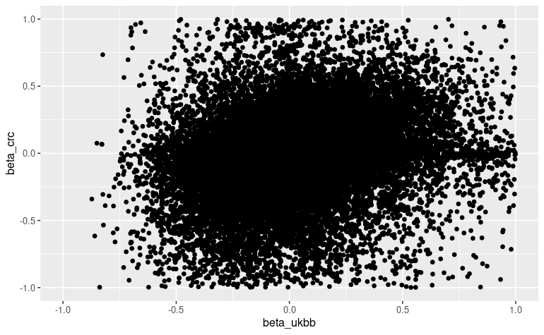

```r
library(ggplot2)
ggplot(merged, aes(beta_ukbb, beta_crc)) + geom_point() + xlim(-1,1) + ylim(-1,1)
```